# Regularization methods – Hands-on

v-1.3

Prof. Dario Gregori – Dott. Corrado Lanera

# Outline

- Preamble
  - Aims
  - Packages and functions
- Execution
  - Load and manage data
  - Cross validation setup
  - Ridge
    - cv-Ridge train
    - Ridge predicting functions
    - cv-Ridge training and test validation
    - Visualization
    - caret
    - glmnet
  - Lasso
    - caret
    - glmnet
  - ENet
    - caret
    - glmnet
- Best models comparison
- Features’ coefficient paths
- Links

# Preamble

## Aims

Main aims of this hands-on are:

Let’s assume that we have wide, sparse, collinear or big data. If your training set falls into any of those categories, it might be a good idea to use a regularized glm.

1. estimate and compare the performance of linear models build upon different regularization methods, in terms of test-RMSE (Root Mean Squared Error):
   - OLS (none)
   - Ridge ($\ell_2$)
   - Lasso ($\ell_1$)
   - ENet (convex combination between Ridge and Lasso)
2. introduce relevant packages and their respective functions:
   - `MASS` (Ridge)
   - `glmnet` (Lasso, Ridge, Enet, …)
   - (`caret`)
   - `ElemStatLearn` (Data)
3. show both explicit (manual) cross-validation (CV) and ready-to-use built-in functions for automatic CV features.

We illustrate the techniques we train a model to predict the `lpsa` (prostate specific antigen log level), based on the predictors provided by the data set `?ElemStatLearn::prostate`, i.e.:

```
- `lcavol`  : log(cancer volume)
- `lweight` : log(prostate weight)
- `age`     : age
- `lbph`    : log(benign prostatic hyperplasia amount)
- `sve`     : seminal vesicle invasion
- `lcp`     : log of capsular penetration
- `gleason` : Gleason score
- `pgg45`   : percent of Gleason score 4 or 5

- `lpsa`    : prostate specific antigen log level
```

For the ridge part, we will use the `MASS` package to provide a full computation of the results. After that we provide an alternative faster solution both using the `caret` and the `glmnet` procedures. For lasso and enet, we consider only the `caret` and the `glmnet` procedures.

## Packages

```r
library(MASS)
library(glmnet)
library(caret)
library(tidyverse)
```

### `MASS`

`MASS` is a package containing functions and data sets to support **Modern Applied Statistics with S (4th edition, 2002)**, by Bill Venables Brian Ripley (http://www.stats.ox.ac.uk/~ripley/)

We will use the `lm.ridge()` from this package that implements the ridge regression. This function give us the motivation to perform all the interested computation step by step (often embedded into single higher level function).

```r
citation('MASS')
```

```
  Venables, W. N. & Ripley, B. D. (2002) Modern Applied Statistics with S.
  Fourth Edition. Springer, New York. ISBN 0-387-95457-0

A BibTeX entry for LaTeX users is

  @Book{,
    title = {Modern Applied Statistics with S},
    author = {W. N. Venables and B. D. Ripley},
    publisher = {Springer},
    edition = {Fourth},
    address = {New York},
    year = {2002},
    note = {ISBN 0-387-95457-0},
    url = {http://www.stats.ox.ac.uk/pub/MASS4/},
  }
```

### `glmnet`

`glmnet` is a package providing a function (`glmnet()`), among other related utilities, that fits a glm via penalized maximum likelihood.

The regularization path is computed for the LASSO or elastic-net penalty at a grid of values for the regularization parameter lambda.

The algorithm is **extremely fast** (via a Mortran back-end, which is an extension of Fortran used for scientific computation)), and can exploit **sparsity** in the input matrix X

The `glmnet` package is a fast implementation, but it requires some extra processing up-front to your data if it is not already represented as a numeric matrix, e.g. if you have **categorical data** or **missing data**, you **need to deal with that yourself**.

```r
citation('glmnet')
```

```
  Jerome Friedman, Trevor Hastie, Robert Tibshirani (2010). Regularization
  Paths for Generalized Linear Models via Coordinate Descent. Journal of
  Statistical Software, 33(1), 1-22. URL http://www.jstatsoft.org/v33/i01/.

If coxnet is used, please also cite:

  Noah Simon, Jerome Friedman, Trevor Hastie, Rob Tibshirani (2011).
  Regularization Paths for Cox's Proportional Hazards Model via Coordinate
  Descent. Journal of Statistical Software, 39(5), 1-13. URL
  http://www.jstatsoft.org/v39/i05/.

To see these entries in BibTeX format, use 'print(<citation>, bibtex=TRUE)',
'toBibtex(.)', or set 'options(citation.bibtex.max=999)'.
```

```r
tidyverse_conflicts()
```

## Functions

```r
?MASS::lm.ridge
```

```
lm.ridge(formula, data, subset,     # formula, data and subselection of rows

    lambda = 0,                    # scalar (or vector) of Ridge constant(s)

    [...],                         # there are more entries, see `?lm.ridge`
    ...
)
```

```r
?glmnet::glmnet
```

```
glmnet(x, y,
    weights,                                           # observation weights

    alpha   = 1,       # The elasticnet mixing parameter, with 0 ≤ alpha ≤ 1
                       # (0 for ridge, 1 for lasso)

    nlambda = 100,     # Number of lambdas considered

    lambda  = NULL,        # User provided set of lambda (but not only one!)
                           # for this function, this option is not
                           # suggested, reed the documentation!

    standardize = TRUE, # flag for standardization.
                        # note: coefficient are always returned on the
                        # original scale

    intercept   = TRUE, # intercept is fitted (TRUE) or set to zero (FALSE)

    [...]                            # there are more entries, see `?glmnet`
)
```

```r
?glmnet::cv.glmnet
```

```
cv.glmnet(x, y,
    type.measure = "deviance",  # 'deviance' is the same as 'mse'; there are
                                # five options, see the documentation for
                                # more information about them `?cv.glmnet`

    nfolds = 10,                       # number of fold for cross validation

    foldid,      # optional vector of values between 1 and nfold identifying
                 # what fold each observation is in. If supplied, nfold can
                 # be missing

    [...],                         # there are more entries, see `?cv.glmnet`

    ...                     # Other arguments that can be passed to `glmnet`
)
```

#Execution

## Load and manage data

```r
# prostate is a dataset from package ElemStatLearn which is no more into CRAN
# you can see it documentation at https://web.stanford.edu/~hastie/ElemStatLearn/datasets/prostate.info.txt
# other dataset from within that package at https://web.stanford.edu/~hastie/ElemStatLearn/data.html
prostate <- readRDS(file.path("data", "prostate.rds"))
prostate
```

|  | lcavol | lweight | age | lbph | svi | lcp | gleason | pgg45 | lpsa | train |
| --- | --- | --- | --- | --- | --- | --- | --- | --- | --- | --- |
| 1 | -0.579818495 | 2.769459 | 50 | -1.38629436 | 0 | -1.38629436 | 6 | 0 | -0.4307829 | TRUE |
| 2 | -0.994252273 | 3.319626 | 58 | -1.38629436 | 0 | -1.38629436 | 6 | 0 | -0.1625189 | TRUE |
| 3 | -0.510825624 | 2.691243 | 74 | -1.38629436 | 0 | -1.38629436 | 7 | 20 | -0.1625189 | TRUE |
| 4 | -1.203972804 | 3.282789 | 58 | -1.38629436 | 0 | -1.38629436 | 6 | 0 | -0.1625189 | TRUE |
| 5 | 0.751416089 | 3.432373 | 62 | -1.38629436 | 0 | -1.38629436 | 6 | 0 | 0.3715636 | TRUE |
| 6 | -1.049822124 | 3.228826 | 50 | -1.38629436 | 0 | -1.38629436 | 6 | 0 | 0.7654678 | TRUE |
| 7 | 0.737164066 | 3.473518 | 64 | 0.61518564 | 0 | -1.38629436 | 6 | 0 | 0.7654678 | FALSE |
| 8 | 0.693147181 | 3.539509 | 58 | 1.53686722 | 0 | -1.38629436 | 6 | 0 | 0.8544153 | TRUE |
| 9 | -0.776528789 | 3.539509 | 47 | -1.38629436 | 0 | -1.38629436 | 6 | 0 | 1.0473190 | FALSE |
| 10 | 0.223143551 | 3.244544 | 63 | -1.38629436 | 0 | -1.38629436 | 6 | 0 | 1.0473190 | FALSE |

[output cut: 87 more lines]

```r
prostate <- dplyr::select(prostate, -train)
prostate
```

|  | lcavol | lweight | age | lbph | svi | lcp | gleason | pgg45 | lpsa |
| --- | --- | --- | --- | --- | --- | --- | --- | --- | --- |
| 1 | -0.579818495 | 2.769459 | 50 | -1.38629436 | 0 | -1.38629436 | 6 | 0 | -0.4307829 |
| 2 | -0.994252273 | 3.319626 | 58 | -1.38629436 | 0 | -1.38629436 | 6 | 0 | -0.1625189 |
| 3 | -0.510825624 | 2.691243 | 74 | -1.38629436 | 0 | -1.38629436 | 7 | 20 | -0.1625189 |
| 4 | -1.203972804 | 3.282789 | 58 | -1.38629436 | 0 | -1.38629436 | 6 | 0 | -0.1625189 |
| 5 | 0.751416089 | 3.432373 | 62 | -1.38629436 | 0 | -1.38629436 | 6 | 0 | 0.3715636 |
| 6 | -1.049822124 | 3.228826 | 50 | -1.38629436 | 0 | -1.38629436 | 6 | 0 | 0.7654678 |
| 7 | 0.737164066 | 3.473518 | 64 | 0.61518564 | 0 | -1.38629436 | 6 | 0 | 0.7654678 |
| 8 | 0.693147181 | 3.539509 | 58 | 1.53686722 | 0 | -1.38629436 | 6 | 0 | 0.8544153 |
| 9 | -0.776528789 | 3.539509 | 47 | -1.38629436 | 0 | -1.38629436 | 6 | 0 | 1.0473190 |
| 10 | 0.223143551 | 3.244544 | 63 | -1.38629436 | 0 | -1.38629436 | 6 | 0 | 1.0473190 |

[output cut: 87 more lines]

## Cross validation setup

First of all we create a partition of the data in train and test set. Test set is a sub-sample that never appears during the training phase, and is used only for the final performance analysis. We use $70 \%$ of the data to train the models and the remaining $30 \%$ to test them.

```r
set.seed(1)
(train_idx <- caret::createDataPartition(prostate$lpsa, p = 0.7)[[1]])
```

```
 [1]  1  2  4  5  6  7  9 10 11 12 14 15 16 18 19 22 23 25 26 27 28 29 30 31 34 35 37
[28] 38 39 40 41 44 45 46 48 49 51 52 53 56 57 58 60 61 62 63 64 65 66 69 71 72 73 77
[55] 78 79 80 81 82 84 85 86 88 89 90 91 92 93 96 97
```

```r
(train_set <- prostate[train_idx, ])
```

|  | lcavol | lweight | age | lbph | svi | lcp | gleason | pgg45 | lpsa |
| --- | --- | --- | --- | --- | --- | --- | --- | --- | --- |
| 1 | -0.579818495 | 2.769459 | 50 | -1.3862944 | 0 | -1.38629436 | 6 | 0 | -0.4307829 |
| 2 | -0.994252273 | 3.319626 | 58 | -1.3862944 | 0 | -1.38629436 | 6 | 0 | -0.1625189 |
| 4 | -1.203972804 | 3.282789 | 58 | -1.3862944 | 0 | -1.38629436 | 6 | 0 | -0.1625189 |
| 5 | 0.751416089 | 3.432373 | 62 | -1.3862944 | 0 | -1.38629436 | 6 | 0 | 0.3715636 |
| 6 | -1.049822124 | 3.228826 | 50 | -1.3862944 | 0 | -1.38629436 | 6 | 0 | 0.7654678 |
| 7 | 0.737164066 | 3.473518 | 64 | 0.6151856 | 0 | -1.38629436 | 6 | 0 | 0.7654678 |
| 9 | -0.776528789 | 3.539509 | 47 | -1.3862944 | 0 | -1.38629436 | 6 | 0 | 1.0473190 |
| 10 | 0.223143551 | 3.244544 | 63 | -1.3862944 | 0 | -1.38629436 | 6 | 0 | 1.0473190 |
| 11 | 0.254642218 | 3.604138 | 65 | -1.3862944 | 0 | -1.38629436 | 6 | 0 | 1.2669476 |
| 12 | -1.347073648 | 3.598681 | 63 | 1.2669476 | 0 | -1.38629436 | 6 | 0 | 1.2669476 |

[output cut: 60 more lines]

```r
(test_set  <- prostate[-train_idx, ])
```

|  | lcavol | lweight | age | lbph | svi | lcp | gleason | pgg45 | lpsa |
| --- | --- | --- | --- | --- | --- | --- | --- | --- | --- |
| 3 | -0.5108256 | 2.691243 | 74 | -1.38629436 | 0 | -1.3862944 | 7 | 20 | -0.1625189 |
| 8 | 0.6931472 | 3.539509 | 58 | 1.53686722 | 0 | -1.3862944 | 6 | 0 | 0.8544153 |
| 13 | 1.6134299 | 3.022861 | 63 | -1.38629436 | 0 | -0.5978370 | 7 | 30 | 1.2669476 |
| 17 | -0.4155154 | 3.516013 | 70 | 1.24415459 | 0 | -0.5978370 | 7 | 30 | 1.4701758 |
| 20 | 0.1823216 | 3.825375 | 70 | 1.65822808 | 0 | -1.3862944 | 6 | 0 | 1.5993876 |
| 21 | 1.1474025 | 3.419365 | 59 | -1.38629436 | 0 | -1.3862944 | 6 | 0 | 1.6389967 |
| 24 | 1.7817091 | 3.451574 | 63 | 0.43825493 | 0 | 1.1786550 | 7 | 60 | 1.7137979 |
| 32 | 0.1823216 | 3.804438 | 65 | 1.70474809 | 0 | -1.3862944 | 6 | 0 | 2.0082140 |
| 33 | 1.2753628 | 3.037354 | 71 | 1.26694760 | 0 | -1.3862944 | 6 | 0 | 2.0082140 |
| 36 | 1.3083328 | 4.119850 | 64 | 2.17133681 | 0 | -1.3862944 | 7 | 5 | 2.0856721 |

[output cut: 17 more lines]

```r
y_test <- dplyr::select(test_set, lpsa) %>% as.matrix
```

After that, we show one possible way to create the partition of the training set for the cross validation (k = 10 folds). Here we use the function `createFolds` from provided by `caret`. **Important note:** we must use the same seed in `set.seed` in order to identify the same partition.

```r
k <- 10
set.seed(1234)
cv_train <- caret::createFolds(train_set$lpsa,
    k           = k,
    list        = TRUE,
    returnTrain = TRUE
)
set.seed(1234)
cv_validation <- createFolds(train_set$lpsa,
    k           = k,
    list        = TRUE,
    returnTrain = FALSE
)
```

## Ridge

### cv-Ridge train

For Ridge, we want to identify the best value for lambda to use in the final model, performing the selection via $k$ folds cross-validation.

So, for each value of lambda ($>= 0$) defined, we train a model on each of the subset identified by the training partition.

The resulting object will be a list of as many elements as the number of lambdas considered, each of them be a list of as many element as the number of folds in the cross validation, each of them is the trained model (for that lambda on that fold)

```r
lambdas <- seq(from = 0, to = 50, by = 0.1)

ridge_models <- map(lambdas,
    function(lambda) {
        map(.x = cv_train,

            ## This dot means "all the other variables"
            #
            ~ MASS::lm.ridge(lpsa ~ .,
                data   = train_set[.x, ],
                lambda = lambda
            )
        )
    }
)

names(ridge_models) <- lambdas

lambdas
```

```
  [1]  0.0  0.1  0.2  0.3  0.4  0.5  0.6  0.7  0.8  0.9  1.0  1.1  1.2  1.3  1.4  1.5
 [17]  1.6  1.7  1.8  1.9  2.0  2.1  2.2  2.3  2.4  2.5  2.6  2.7  2.8  2.9  3.0  3.1
 [33]  3.2  3.3  3.4  3.5  3.6  3.7  3.8  3.9  4.0  4.1  4.2  4.3  4.4  4.5  4.6  4.7
 [49]  4.8  4.9  5.0  5.1  5.2  5.3  5.4  5.5  5.6  5.7  5.8  5.9  6.0  6.1  6.2  6.3
 [65]  6.4  6.5  6.6  6.7  6.8  6.9  7.0  7.1  7.2  7.3  7.4  7.5  7.6  7.7  7.8  7.9
 [81]  8.0  8.1  8.2  8.3  8.4  8.5  8.6  8.7  8.8  8.9  9.0  9.1  9.2  9.3  9.4  9.5
 [97]  9.6  9.7  9.8  9.9 10.0 10.1 10.2 10.3 10.4 10.5 10.6 10.7 10.8 10.9 11.0 11.1
[113] 11.2 11.3 11.4 11.5 11.6 11.7 11.8 11.9 12.0 12.1 12.2 12.3 12.4 12.5 12.6 12.7
[129] 12.8 12.9 13.0 13.1 13.2 13.3 13.4 13.5 13.6 13.7 13.8 13.9 14.0 14.1 14.2 14.3
[145] 14.4 14.5 14.6 14.7 14.8 14.9 15.0 15.1 15.2 15.3 15.4 15.5 15.6 15.7 15.8 15.9
[161] 16.0 16.1 16.2 16.3 16.4 16.5 16.6 16.7 16.8 16.9 17.0 17.1 17.2 17.3 17.4 17.5
[177] 17.6 17.7 17.8 17.9 18.0 18.1 18.2 18.3 18.4 18.5 18.6 18.7 18.8 18.9 19.0 19.1
[193] 19.2 19.3 19.4 19.5 19.6 19.7 19.8 19.9 20.0 20.1 20.2 20.3 20.4 20.5 20.6 20.7
[209] 20.8 20.9 21.0 21.1 21.2 21.3 21.4 21.5 21.6 21.7 21.8 21.9 22.0 22.1 22.2 22.3
[225] 22.4 22.5 22.6 22.7 22.8 22.9 23.0 23.1 23.2 23.3 23.4 23.5 23.6 23.7 23.8 23.9
```

[output cut: 17 more lines]

```r
class(ridge_models)
```

```
[1] "list"
```

```r
length(ridge_models)
```

```
[1] 501
```

```r
str(ridge_models, 1, list.len = 10)        # one CV each value of lambda
```

```
List of 501
 $ 0   :List of 10
 $ 0.1 :List of 10
 $ 0.2 :List of 10
 $ 0.3 :List of 10
 $ 0.4 :List of 10
 $ 0.5 :List of 10
 $ 0.6 :List of 10
 $ 0.7 :List of 10
 $ 0.8 :List of 10
 $ 0.9 :List of 10
  [list output truncated]
```

```r
str(ridge_models[[1]], 1)                      # one ridge for each fold
```

```
List of 10
 $ Fold01:List of 9
  ..- attr(*, "class")= chr "ridgelm"
 $ Fold02:List of 9
  ..- attr(*, "class")= chr "ridgelm"
 $ Fold03:List of 9
  ..- attr(*, "class")= chr "ridgelm"
 $ Fold04:List of 9
  ..- attr(*, "class")= chr "ridgelm"
 $ Fold05:List of 9
  ..- attr(*, "class")= chr "ridgelm"
 $ Fold06:List of 9
  ..- attr(*, "class")= chr "ridgelm"
 $ Fold07:List of 9
  ..- attr(*, "class")= chr "ridgelm"
 $ Fold08:List of 9
  ..- attr(*, "class")= chr "ridgelm"
 $ Fold09:List of 9
  ..- attr(*, "class")= chr "ridgelm"
 $ Fold10:List of 9
  ..- attr(*, "class")= chr "ridgelm"
```

```r
str(ridge_models[[1]][[1]], 1)                   # content of each model
```

```
List of 9
 $ coef  : Named num [1:8] 0.6328 0.2151 -0.0983 0.1936 0.2873 ...
  ..- attr(*, "names")= chr [1:8] "lcavol" "lweight" "age" "lbph" ...
 $ scales: Named num [1:8] 1.178 0.421 7.307 1.444 0.393 ...
  ..- attr(*, "names")= chr [1:8] "lcavol" "lweight" "age" "lbph" ...
 $ Inter : int 1
 $ lambda: num 0
 $ ym    : num 2.45
 $ xm    : Named num [1:8] 1.2165 3.5876 63.254 -0.0267 0.1905 ...
  ..- attr(*, "names")= chr [1:8] "lcavol" "lweight" "age" "lbph" ...
 $ GCV   : Named num 0.00959
  ..- attr(*, "names")= chr "0"
 $ kHKB  : num 4.94
 $ kLW   : num 3.64
 - attr(*, "class")= chr "ridgelm"
```

```r
str(ridge_models[[2]][[1]], 1)                   # content of each model
```

```
List of 9
 $ coef  : Named num [1:8] 0.6305 0.215 -0.0973 0.1933 0.2866 ...
  ..- attr(*, "names")= chr [1:8] "lcavol" "lweight" "age" "lbph" ...
 $ scales: Named num [1:8] 1.178 0.421 7.307 1.444 0.393 ...
  ..- attr(*, "names")= chr [1:8] "lcavol" "lweight" "age" "lbph" ...
 $ Inter : int 1
 $ lambda: num 0.1
 $ ym    : num 2.45
 $ xm    : Named num [1:8] 1.2165 3.5876 63.254 -0.0267 0.1905 ...
  ..- attr(*, "names")= chr [1:8] "lcavol" "lweight" "age" "lbph" ...
 $ GCV   : Named num 0.00958
  ..- attr(*, "names")= chr "0.1"
 $ kHKB  : num 4.94
 $ kLW   : num 3.64
 - attr(*, "class")= chr "ridgelm"
```

```r
class(ridge_models[[1]][[1]])                      # class of the models
```

```
[1] "ridgelm"
```

### Ridge predicting functions

[output not shown]

[output cut: 60 more lines]

Now it could be useful to define a function to apply to our data structures to quickly perform the prediction given a value of lambda and the indexes of data we want to test (to avoid its repetition each steps).

```r
lambda_predictions <- function(ridge, lambda, index) {

    ## We want tu use lambda to subset our data, so we have to convert
    ## it as characters
    #
    lambda <- as.character(lambda)

    ## Here we suppose our data structure, i.e. we explicitely use
    ## `prostate` and `lpsa` into the function, which is not a good idea
    ## in general when we are programming. Anyway we suppose that this
    ## way (without enter deeply in a "good" way to write a function)
    ## the idea behind this function and its application it could be
    ## simpler to understand.
    ##
    ## Moreover we know that for each value of lambda we have the same
    ## number of model as the number of folds, so we can use `map2` to
    ## go parallel on both the model and the relative set of indeces
    ## (the training or the test one)
    #
    map2(.x = ridge[[lambda]], .y = index,
        ~ predict.ridgelm(model = .x,
            new_x = dplyr::select(train_set[.y, ], -lpsa),
            new_y = dplyr::select(train_set[.y, ], lpsa)[[1]]
        )
    )
}

ridge_models[['0']]
```

```
$Fold01
                   lcavol      lweight          age         lbph          svi
-0.436119931  0.537409398  0.511226578 -0.013449690  0.134056905  0.731704767
         lcp      gleason        pgg45
-0.133598493  0.137055154  0.006455319

$Fold02
                   lcavol      lweight          age         lbph          svi
 0.881141817  0.682811234  0.220072487 -0.026386399  0.179862948  0.821677382
         lcp      gleason        pgg45
-0.169840862  0.175812282  0.007249171

$Fold03
                   lcavol      lweight          age         lbph          svi
-1.483681184  0.566298433  0.640296044 -0.016076201  0.076312405  0.745852728
         lcp      gleason        pgg45
-0.153125585  0.241150064  0.005796463

$Fold04
                   lcavol      lweight          age         lbph          svi
-1.674176622  0.532070077  0.552411604 -0.004671312  0.060440076  0.685576813
         lcp      gleason        pgg45
-0.148128503  0.219794756  0.004964924

$Fold05
                   lcavol      lweight          age         lbph          svi
-0.465368242  0.529130877  0.521346484 -0.009522739  0.117779023  0.685481966
         lcp      gleason        pgg45
-0.087774305  0.104835119  0.006144900

$Fold06
                   lcavol      lweight          age         lbph          svi
-0.280392323  0.534634681  0.490836897 -0.008183197  0.121770906  0.921262471
         lcp      gleason        pgg45
-0.134551419  0.076367649  0.006044729

$Fold07
                   lcavol      lweight          age         lbph          svi
-0.406612590  0.534002656  0.529560382 -0.013968392  0.109496874  0.681870927
         lcp      gleason        pgg45
-0.129050952  0.128806548  0.006996554

$Fold08
                   lcavol      lweight          age         lbph          svi
 0.005755933  0.565397188  0.469513947 -0.013289425  0.117280255  0.683222415
         lcp      gleason        pgg45
-0.208858655  0.063350831  0.010848356

$Fold09
                   lcavol      lweight          age         lbph          svi
-0.461059244  0.504114715  0.474953348 -0.014385691  0.151142086  0.864852256
         lcp      gleason        pgg45
-0.100801338  0.168253303  0.006664069

$Fold10
                   lcavol      lweight          age         lbph          svi
-0.729847396  0.545900708  0.719879078 -0.019992861  0.099434814  0.787098227
         lcp      gleason        pgg45
-0.133445864  0.118602031  0.006936717
```

```r
lambda_predictions(ridge_models, lambda = 0, index = cv_validation) %>%
    str()
```

```
List of 10
 $ Fold01:List of 2
  ..$ y_hat: tibble [7 × 1] (S3: tbl_df/tbl/data.frame)
  .. ..$ 0: num [1:7] 1.97 1.15 2.7 2.84 2.49 ...
  ..$ mse  : Named num 0.286
  .. ..- attr(*, "names")= chr "0"
 $ Fold02:List of 2
  ..$ y_hat: tibble [7 × 1] (S3: tbl_df/tbl/data.frame)
  .. ..$ 0: num [1:7] 2.886 1.628 0.861 1.972 0.767 ...
  ..$ mse  : Named num 1.32
  .. ..- attr(*, "names")= chr "0"
 $ Fold03:List of 2
  ..$ y_hat: tibble [7 × 1] (S3: tbl_df/tbl/data.frame)
  .. ..$ 0: num [1:7] 0.801 2.164 2.483 2.683 3.564 ...
  ..$ mse  : Named num 0.442
  .. ..- attr(*, "names")= chr "0"
 $ Fold04:List of 2
  ..$ y_hat: tibble [8 × 1] (S3: tbl_df/tbl/data.frame)
  .. ..$ 0: num [1:8] 1.38 2.14 2.27 1.8 3 ...
  ..$ mse  : Named num 0.465
  .. ..- attr(*, "names")= chr "0"
 $ Fold05:List of 2
  ..$ y_hat: tibble [7 × 1] (S3: tbl_df/tbl/data.frame)
  .. ..$ 0: num [1:7] 0.774 2.453 1.317 2.323 2.46 ...
  ..$ mse  : Named num 0.481
  .. ..- attr(*, "names")= chr "0"
 $ Fold06:List of 2
  ..$ y_hat: tibble [7 × 1] (S3: tbl_df/tbl/data.frame)
  .. ..$ 0: num [1:7] 0.836 1.775 2.204 4.179 1.585 ...
  ..$ mse  : Named num 1.3
  .. ..- attr(*, "names")= chr "0"
 $ Fold07:List of 2
  ..$ y_hat: tibble [6 × 1] (S3: tbl_df/tbl/data.frame)
  .. ..$ 0: num [1:6] 0.679 1.53 2.349 3.007 3.693 ...
  ..$ mse  : Named num 0.245
  .. ..- attr(*, "names")= chr "0"
 $ Fold08:List of 2
  ..$ y_hat: tibble [7 × 1] (S3: tbl_df/tbl/data.frame)
  .. ..$ 0: num [1:7] 0.771 1.184 2.092 1.813 2.922 ...
  ..$ mse  : Named num 0.554
  .. ..- attr(*, "names")= chr "0"
 $ Fold09:List of 2
  ..$ y_hat: tibble [6 × 1] (S3: tbl_df/tbl/data.frame)
  .. ..$ 0: num [1:6] 1.05 2.33 2.47 4.01 3.5 ...
  ..$ mse  : Named num 0.439
  .. ..- attr(*, "names")= chr "0"
 $ Fold10:List of 2
  ..$ y_hat: tibble [8 × 1] (S3: tbl_df/tbl/data.frame)
  .. ..$ 0: num [1:8] 1.754 1.797 2.084 0.931 3.394 ...
  ..$ mse  : Named num 0.376
  .. ..- attr(*, "names")= chr "0"
```

### cv-Ridge training and test validation

Now we finally can perform our prediction on each fold for each value of lambda.

```r
train_rmse <- lambdas %>%

    ## for any given value of lambda we want to compute all the 10 fold
    ## training errors
    #
    map(~ lambda_predictions(ridge_models, lambda = ., cv_train)) %>%  # str(2, list.len = 10)

    ## the resulting output is a list of lambda * k fold predictions, in
    ## each one, and for each fold within, we extract the mse, compute
    ## the mean and its square root.
    map_dbl(function(folds) {
        map_dbl(folds, ~ .$mse) %>%
        mean %>%
        sqrt
    }) %>%

    ## finally we assure that for each mse it is attached the
    ## corresponding value of lambda for which it was cross validated
    ## computed
    setNames(lambdas)

train_rmse %>% str(1)
```

```
 Named num [1:501] 0.659 0.659 0.659 0.659 0.659 ...
 - attr(*, "names")= chr [1:501] "0" "0.1" "0.2" "0.3" ...
```

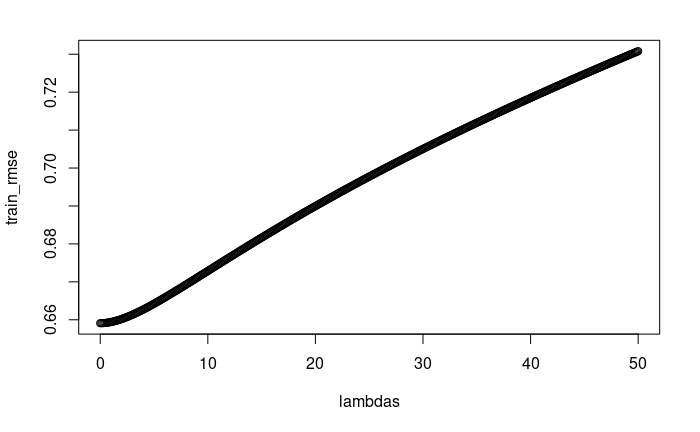

```r
plot(lambdas, train_rmse)
```

As expected the rmse grow-up monotonically as lambda becomes greater.

Now, do the same for the test (validation) set

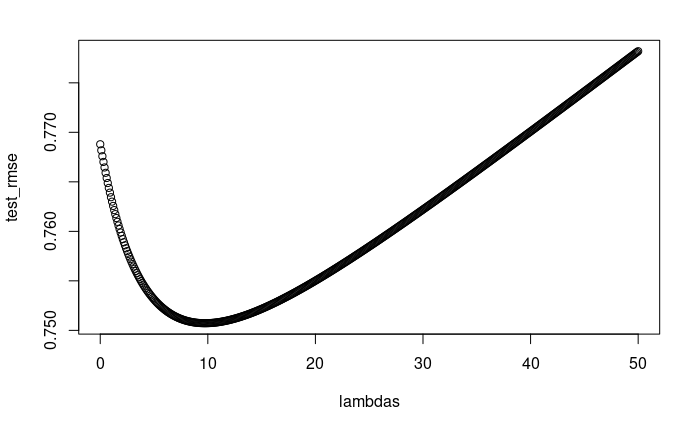

```r
test_rmse <- lambdas %>%

    ## here we have substitute cv_train with cv_validation, and this is
    ## the only difference!
    map(
        ~lambda_predictions(ridge_models, lambda = ., cv_validation)
    ) %>%
    map_dbl(function(folds) {
        map_dbl(folds, ~ .$mse) %>%
        mean %>%
        sqrt
    }) %>%
    setNames(lambdas)

plot(lambdas, test_rmse)
```

```r
range(test_rmse)
```

```
[1] 0.7507222 0.7781946
```

Here too, as expected, the validation (test) error decreases as lambda becomes greater (and model become less flexible) until a minimum is reached and next is start to grow-up because the bias introduced start to became too high.

### Visualization

We now have all the information to create a summary data frame and plots the results obtained

```r
ridge_results <- tibble(
        lambda = lambdas,
        train  = train_rmse,
        test   = test_rmse
    ) %>%

    ## gather is useful to gather more than one column into a couple of
    ## ley-value ones
    #
    gather(
        key   = split,
        value = rmse,
        train, test
    )
ridge_results %>% filter(split == 'test')
```

| lambda | split | rmse |
| --- | --- | --- |
| 0.0 | test | 0.7687963 |
| 0.1 | test | 0.7681818 |
| 0.2 | test | 0.7675867 |
| 0.3 | test | 0.7670103 |
| 0.4 | test | 0.7664519 |
| 0.5 | test | 0.7659109 |
| 0.6 | test | 0.7653868 |
| 0.7 | test | 0.7648790 |
| 0.8 | test | 0.7643870 |
| 0.9 | test | 0.7639103 |

[output cut: 491 more lines]

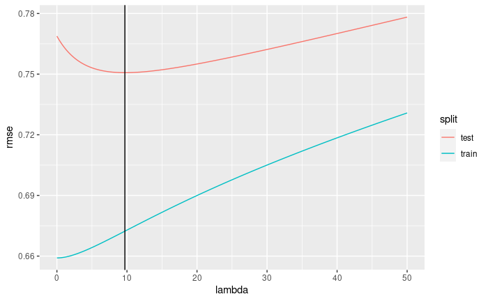

```r
best_lambda <- which.min(test_rmse) %>% lambdas[.]

ggplot(ridge_results, aes(x = lambda, y = rmse, colour = split)) +
    geom_line() +
    geom_vline(aes(xintercept = best_lambda))
```

Our best lambda for the validation set is

```r
best_lambda
```

```
[1] 9.7
```

and so we finally consider it for the final model

```r
best_ridge_mass <- MASS::lm.ridge(lpsa ~ .,
    data   = train_set, # all!
    lambda = best_lambda
)

ridge_mass <- predict.ridgelm(best_ridge_mass,
        new_x = dplyr::select(test_set, -lpsa),
        new_y = dplyr::select(test_set, lpsa)[[1]]
    )$mse %>%
    sqrt

ridge_mass
```

```
      9.7
0.7497118
```

### caret

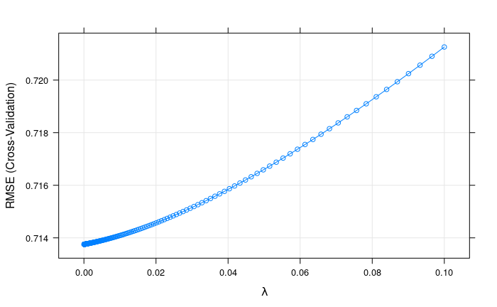

```r
cv_Ridge_caret <- train(lpsa ~ .,
          data       = train_set,
          method     = 'ridge',
          metric     = "RMSE",
          tuneLength = 200,
          preProc    = c("center", "scale"),
          trControl  = trainControl(
            method ='cv',
            number = 10
          )
)

plot(cv_Ridge_caret, xlab = expression(lambda))
```

Using caret the best performance is

```r
ridge_caret <- (
        predict(cv_Ridge_caret, dplyr::select(test_set, -lpsa)) -
        y_test
    )^2 %>%
    mean %>%
    sqrt

ridge_caret
```

```
[1] 0.729353
```

### glmnet

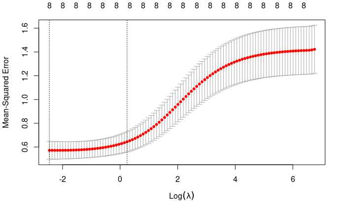

```r
ridge_cv_model <- glmnet::cv.glmnet(
    dplyr::select(train_set, -lpsa) %>% as.matrix,
    dplyr::select(train_set, lpsa)[[1]] %>% as.matrix,
    alpha = 0
)

plot(ridge_cv_model)
```

```r
y_hat_best_ridge <- predict(ridge_cv_model,
    dplyr::select(test_set, -lpsa) %>% as.matrix,
    s = 'lambda.min' # 'lambda.1se'
)

y_hat_1se_ridge <- predict(ridge_cv_model,
    dplyr::select(test_set, -lpsa) %>% as.matrix,
    s = 'lambda.1se'
)

ridge_glmnet <- (y_hat_best_ridge - y_test)^2 %>%
    mean %>%
    sqrt

ridge_glmnet_1se <- (y_hat_1se_ridge - y_test)^2 %>%
    mean %>%
    sqrt

ridge_glmnet
```

```
[1] 0.7391617
```

```r
ridge_glmnet_1se
```

```
[1] 0.8297956
```

## Lasso

### caret

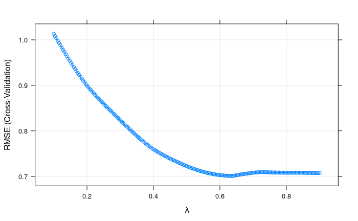

```r
cv_lasso_caret <- train(lpsa ~ .,
          data      = train_set,
          method    = 'lasso',
          metric    = "RMSE",
          tuneLength = 200,
          preProc   = c("center", "scale"),
          trControl = trainControl(
            method ='cv',
            number = 10
          )
)

plot(cv_lasso_caret, xlab = expression(lambda))
```

Using caret the best performance is

```r
lasso_caret <- (
        predict(cv_lasso_caret, dplyr::select(test_set, -lpsa)) -
        y_test
    )^2 %>%
    mean %>%
    sqrt

lasso_caret
```

```
[1] 0.7276407
```

### glmnet

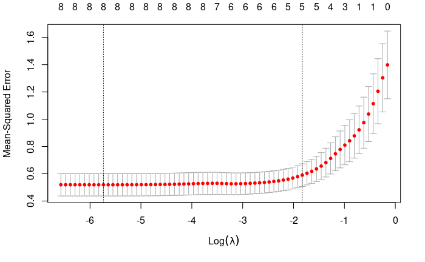

```r
lasso_cv_model <- glmnet::cv.glmnet(
    dplyr::select(train_set, -lpsa) %>% as.matrix,
    dplyr::select(train_set, lpsa)[[1]] %>% as.matrix,
    alpha = 1
)

plot(lasso_cv_model)
```

```r
y_hat_best_lasso <- predict(lasso_cv_model,
    dplyr::select(test_set, -lpsa) %>% as.matrix,
    s = 'lambda.min' # 'lambda.1se'
)

y_hat_1se_lasso <- predict(lasso_cv_model,
    dplyr::select(test_set, -lpsa) %>% as.matrix,
    s = 'lambda.1se'
)

lasso_glmnet <- (y_hat_best_lasso - y_test)^2 %>%
    mean %>%
    sqrt

lasso_glmnet_1se <- (y_hat_1se_lasso - y_test)^2 %>%
    mean %>%
    sqrt

lasso_glmnet
```

```
[1] 0.7291389
```

```r
lasso_glmnet_1se
```

```
[1] 0.7150236
```

## ENet

### caret

```r
cv_enet_caret <- train(lpsa ~ .,
          data       = train_set,
          method     = 'enet',
          metric     = "RMSE",
          tuneLength = 200,
          preProc    = c("center", "scale"),
          trControl = trainControl(
            method ='cv',
            number = 10
          )
)

cv_enet_caret$bestTune
```

|  | fraction | lambda |
| --- | --- | --- |
| 39962 | 0.818593 | 0.1 |

Using caret the best performance is

```r
enet_caret <- (predict(cv_enet_caret,
    dplyr::select(test_set, -lpsa)
) - y_test)^2 %>%
    mean %>%
    sqrt

enet_caret
```

```
[1] 0.7608377
```

### glmnet

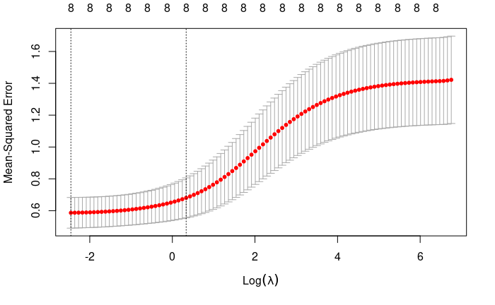

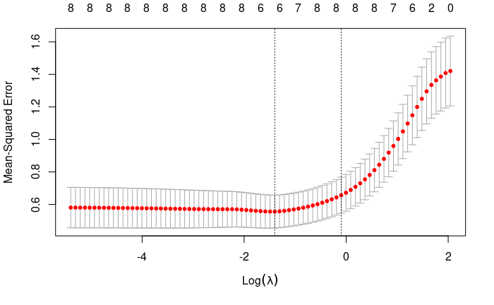

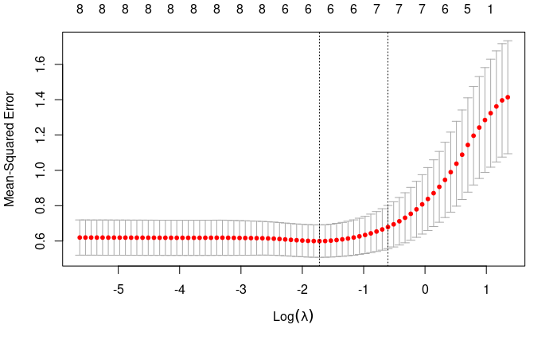

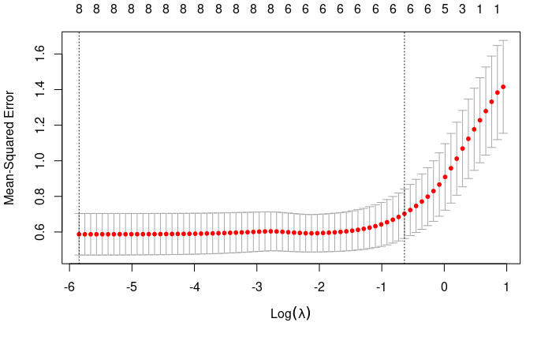

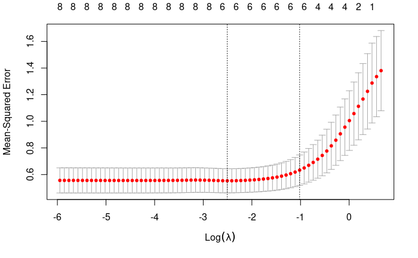

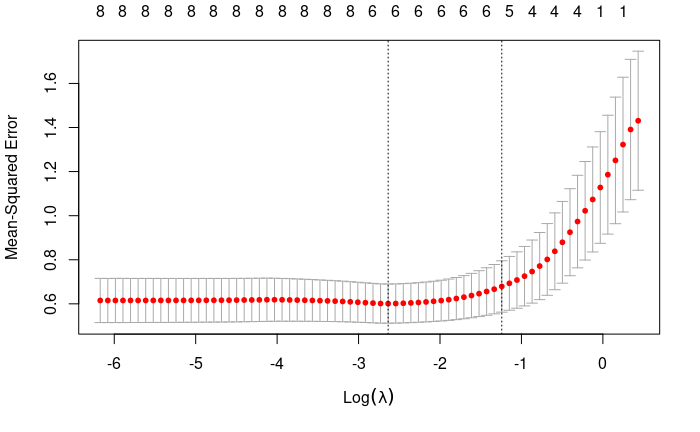

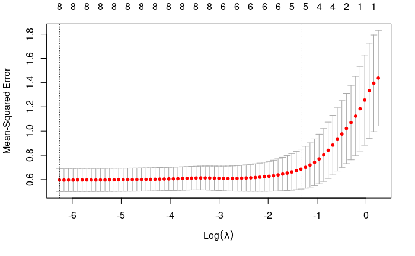

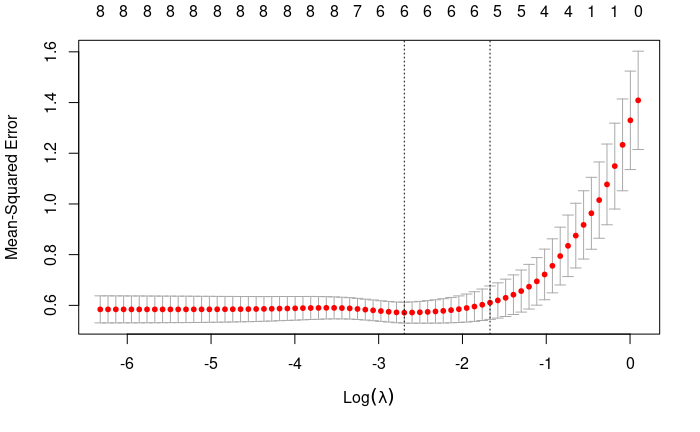

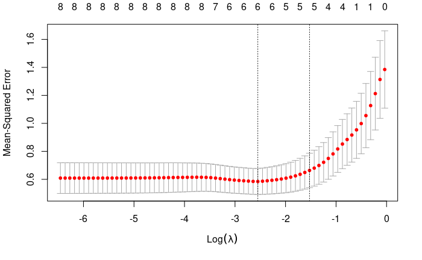

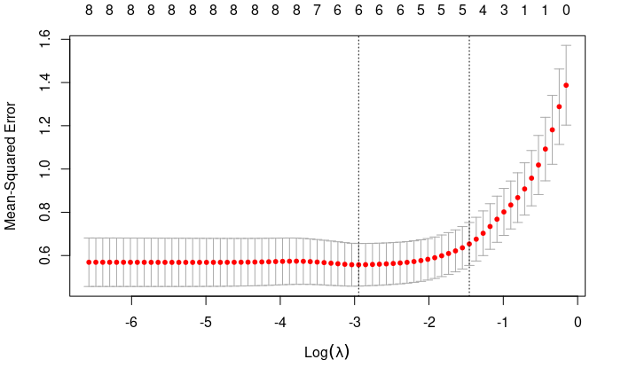

```r
alphas <- seq(0, 1, length.out = 10)

enet_cv_models <- map(alphas,
    ~ glmnet::cv.glmnet(
        dplyr::select(train_set, -lpsa) %>% as.matrix,
        dplyr::select(train_set, lpsa)[[1]] %>% as.matrix,
        alpha = .
    )
)
names(enet_cv_models) <- alphas

walk(enet_cv_models, plot)
```

```r
y_hat_best_enets <- map(enet_cv_models,
    ~ predict(.,
        dplyr::select(test_set, -lpsa) %>% as.matrix,
        s = 'lambda.min' # 'lambda.1se'
    )
)

y_hat_1se_enets <- map(enet_cv_models,
    ~ predict(.,
        dplyr::select(test_set, -lpsa) %>% as.matrix,
        s = 'lambda.1se'
    )
)

enet_glmnet <- map_dbl(y_hat_best_enets,
    ~ (. - y_test)^2 %>%
        mean %>%
        sqrt
)

enet_glmnet_1se <- map_dbl(y_hat_1se_enets,
    ~ (. - y_test)^2 %>%
        mean %>%
        sqrt
)

enet_glmnet
```

```
                0 0.111111111111111 0.222222222222222 0.333333333333333
        0.7391617         0.7549627         0.7452200         0.7294622
0.444444444444444 0.555555555555556 0.666666666666667 0.777777777777778
        0.7390727         0.7366415         0.7293003         0.7306379
0.888888888888889                 1
        0.7248472         0.7293496
```

```r
enet_glmnet_1se
```

```
                0 0.111111111111111 0.222222222222222 0.333333333333333
        0.8343883         0.7890481         0.7564432         0.7547162
0.444444444444444 0.555555555555556 0.666666666666667 0.777777777777778
        0.7365205         0.7283323         0.7257235         0.7185979
0.888888888888889                 1
        0.7210856         0.7281033
```

```r
which.min(enet_glmnet)
```

```
0.888888888888889
                9
```

```r
which.min(enet_glmnet_1se)
```

```
0.777777777777778
                8
```

```r
enet_glmnet     <- enet_glmnet[which.min(enet_glmnet)]
enet_glmnet_1se <- enet_glmnet_1se[which.min(enet_glmnet_1se)]

enet_glmnet
```

```
0.888888888888889
        0.7248472
```

```r
enet_glmnet_1se
```

```
0.777777777777778
        0.7185979
```

# Best models comparison

```r
bests_rms <- c(ridge_mass,
        ridge_caret,
        ridge_glmnet_1se,
        ridge_glmnet,
        lasso_caret,
        lasso_glmnet_1se,
        lasso_glmnet,
        enet_caret,
        enet_glmnet,
        enet_glmnet_1se
)

best_names <- c('ridge_mass',
        'ridge_caret',
        'ridge_glmnet_1se',
        'ridge_glmnet',
        'lasso_caret',
        'lasso_glmnet_1se',
        'lasso_glmnet',
        'enet_caret',
        'enet_glmnet',
        'enet_glmnet_1se'
)

setNames(bests_rms, best_names) %>% sort
```

```
lasso_glmnet_1se  enet_glmnet_1se      enet_glmnet      lasso_caret     lasso_glmnet
       0.7150236        0.7185979        0.7248472        0.7276407        0.7291389
     ridge_caret     ridge_glmnet       ridge_mass       enet_caret ridge_glmnet_1se
       0.7293530        0.7391617        0.7497118        0.7608377        0.8297956
```

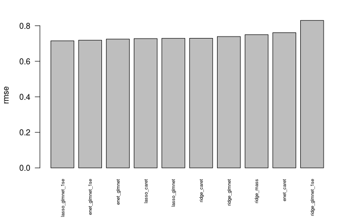

```r
barplot(sort(bests_rms),
    names.arg = best_names[order(bests_rms)],
    ylab = 'rmse',
    las  = 2,
    cex.names = 0.6
)
```

# Features’ coefficient paths

```r
fit_glmnet <- glmnet(
    x = dplyr::select(train_set, -lpsa) %>% as.matrix,
    y = dplyr::select(train_set, lpsa)[[1]] %>% as.matrix
)
```

We can visualize the coefficients by executing the `plot` function.

Each curve corresponds to a variable. It shows the path of its coefficient against the $\ell_1$-norm of the whole coefficient vector at as $\lambda$ varies. IDs of the coefficients can be visualized by `label = TRUE` option.

The axis above indicates the number of nonzero coefficients at the current $\lambda$, which is the effective degrees of freedom for the LASSO.

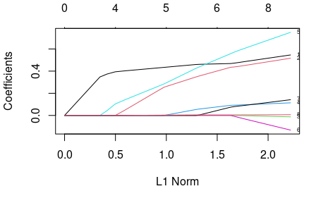

```r
plot(fit_glmnet, label = TRUE)                                    # ?plot.glmnet
```

The `predict()` method for glmnet returns the the estimation of the outcome for each step of regularization

```r
predict(fit_glmnet, newx = dplyr::select(test_set, -lpsa) %>% as.matrix)
```

```
         s0       s1       s2       s3       s4       s5       s6       s7       s8
3  2.461512 2.348318 2.245180 2.151204 2.065578 1.987557 1.916468 1.851695 1.796586
8  2.461512 2.425943 2.393535 2.364005 2.337099 2.312583 2.290245 2.269891 2.246565
13 2.461512 2.485278 2.506933 2.526664 2.544642 2.561023 2.575949 2.589549 2.590516
17 2.461512 2.354463 2.256924 2.168050 2.087072 2.013287 1.946058 1.884800 1.832208
20 2.461512 2.393008 2.330590 2.273717 2.221897 2.174680 2.131658 2.092457 2.055646
21 2.461512 2.455231 2.449508 2.444294 2.439543 2.435214 2.431270 2.427676 2.416341
24 2.461512 2.496128 2.527668 2.556407 2.582593 2.606452 2.628192 2.648000 2.653409
32 2.461512 2.393008 2.330590 2.273717 2.221897 2.174680 2.131658 2.092457 2.055646
33 2.461512 2.463481 2.465276 2.466911 2.468401 2.469758 2.470995 2.472122 2.464165
36 2.461512 2.465607 2.469338 2.472738 2.475836 2.478659 2.481231 2.483574 2.476487
42 2.461512 2.474238 2.485834 2.496400 2.506027 2.514798 2.522791 2.530073 2.526520
43 2.461512 2.418791 2.379866 2.344398 2.312081 2.282636 2.255806 2.231360 2.205105
47 2.461512 2.557130 2.644253 2.723637 2.795968 2.861874 2.921925 2.976641 3.050844
50 2.461512 2.459965 2.458556 2.457272 2.456103 2.455037 2.454065 2.453180 2.443784
```

[output cut: 121 more lines]

# Links

- R help: `?`
- MASS http://www.stats.ox.ac.uk/pub/MASS4/
- `?glm`
- Mortran: https://en.wikipedia.org/wiki/Mortran (extension of Fortran used for scientific computation)
- glmnet http://web.stanford.edu/~hastie/glmnet/glmnet_beta.html
- ESL https://statweb.stanford.edu/~tibs/ElemStatLearn/
[^1]: For more information about *generic* functions and *method* see http://adv-r.had.co.nz/OO-essentials.html